# Homework 2

Irene Yang

2/21/2018

## Setting Up

Installed packages: `car` and `quantreg`. Note: Responded “n” to prompt “Do you want to install from sources the package which needs compilation?”

## Homework on the `Davis` dataset in the `car` package - using the `dplyr` package as much as possible.

### **Question 1:** What kind of R object is the `Davis` dataset?

```r
tbl_df(Davis)
```

```
## # A tibble: 200 x 5
##    sex   weight height repwt repht
##  * <fct>  <int>  <int> <int> <int>
##  1 M         77    182    77   180
##  2 F         58    161    51   159
##  3 F         53    161    54   158
##  4 M         68    177    70   175
##  5 F         59    157    59   155
##  6 M         76    170    76   165
##  7 M         76    167    77   165
##  8 M         69    186    73   180
##  9 M         71    178    71   175
## 10 M         65    171    64   170
## # ... with 190 more rows
```

The `Davis` dataset is a dataframe made up of 200 rows and five columns. The columns describe the sex, weight, height, repwt (reported weight), repht (reported height) of men and women who exercise regularly. Sex is a factor vector and the remaining columns are integer vectors.

### **Question 2:** How many observations are in the `Davis` dataset?

```r
count(Davis)
```

```
## # A tibble: 1 x 1
##       n
##   <int>
## 1   200
```

### **Question 3:** For reported weight, how many observations have a missing value?

```r
summary(Davis)
```

```
##  sex         weight          height          repwt            repht
##  F:112   Min.   : 39.0   Min.   : 57.0   Min.   : 41.00   Min.   :148.0
##  M: 88   1st Qu.: 55.0   1st Qu.:164.0   1st Qu.: 55.00   1st Qu.:160.5
##          Median : 63.0   Median :169.5   Median : 63.00   Median :168.0
##          Mean   : 65.8   Mean   :170.0   Mean   : 65.62   Mean   :168.5
##          3rd Qu.: 74.0   3rd Qu.:177.2   3rd Qu.: 73.50   3rd Qu.:175.0
##          Max.   :166.0   Max.   :197.0   Max.   :124.00   Max.   :200.0
##                                          NA's   :17       NA's   :17
```

There are 17 missing values in the repwt column.

### **Question 4:** How many observations have no missing values? *(HINT: find complete cases)*

```r
Davis %>% count(complete.cases(Davis))
```

```
## # A tibble: 2 x 2
##   `complete.cases(Davis)`     n
##   <lgl>                   <int>
## 1 F                          19
## 2 T                         181
```

181 observations have no missing values.

### **Question 5:** How many females are in this subset?

```r
count(Davis, sex == "F")
```

```
## # A tibble: 2 x 2
##   `sex == "F"`     n
##   <lgl>        <int>
## 1 F               88
## 2 T              112
```

There are 112 females in this subset.

### **Question 6:** What is the average BMI for these individuals?

```r
Davis_BMI <- mutate(Davis, height_m = height/100, BMI = weight/height_m^2)
summary(Davis_BMI)
```

```
##  sex         weight          height          repwt            repht
##  F:112   Min.   : 39.0   Min.   : 57.0   Min.   : 41.00   Min.   :148.0
##  M: 88   1st Qu.: 55.0   1st Qu.:164.0   1st Qu.: 55.00   1st Qu.:160.5
##          Median : 63.0   Median :169.5   Median : 63.00   Median :168.0
##          Mean   : 65.8   Mean   :170.0   Mean   : 65.62   Mean   :168.5
##          3rd Qu.: 74.0   3rd Qu.:177.2   3rd Qu.: 73.50   3rd Qu.:175.0
##          Max.   :166.0   Max.   :197.0   Max.   :124.00   Max.   :200.0
##                                          NA's   :17       NA's   :17
##     height_m          BMI
##  Min.   :0.570   Min.   : 15.82
##  1st Qu.:1.640   1st Qu.: 20.23
##  Median :1.695   Median : 21.84
##  Mean   :1.700   Mean   : 24.70
##  3rd Qu.:1.772   3rd Qu.: 23.94
##  Max.   :1.970   Max.   :510.93
##
```

The average BMI is 24.70.

### **Question 7:** How do these individuals fall into the BMI categories (what are the frequencies and relative %’s)?

```r
Davis_BMICategory <- Davis_BMI %>%
  mutate(BMICategory = case_when(BMI < 18.5 ~ "Underweight",
                                 BMI > 18.5 & BMI < 25 ~ "Normal",
                                 BMI > 25 & BMI < 30 ~ "Overweight",
                                 BMI >= 30 ~ "Obese",
                                 BMI = NA ~ "Missing"))
Davis_BMICategory %>%
  group_by(BMICategory) %>%
  summarize(n = n()) %>%
  mutate(relfreq = n / sum(n) * 100)
```

```
## # A tibble: 4 x 3
##   BMICategory     n relfreq
##   <chr>       <int>   <dbl>
## 1 Normal        143   71.5
## 2 Obese           4    2.00
## 3 Overweight     35   17.5
## 4 Underweight    18    9.00
```

Frequencies and relative frequencies are listed above.

### **Question 8:** Create a histogram of BMI.

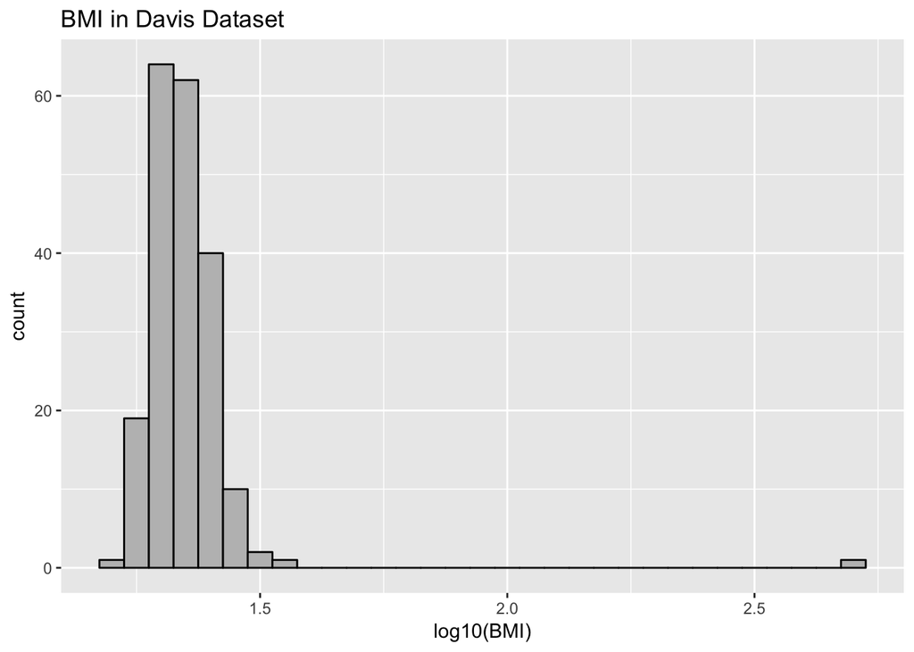

```r
# log10 transformation performed in an attempt to normalize the values (extremely high BMI of 510.93!)
library(ggplot2)
Davis_BMICategory %>%
  ggplot() +
  geom_histogram(aes(log10(BMI)), binwidth = .05, color = "black", fill = "grey") +
  ggtitle("BMI in Davis Dataset")
```

Even with the log transformation, there is an extreme outlier.

### **Question 9:** Create side-by-side boxplots of the BMI distributions by gender

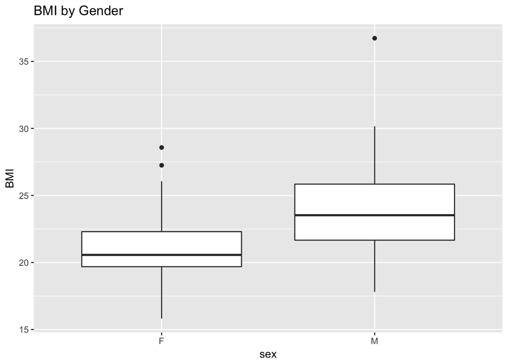

```r
# First, extreme outlier (BMI of 510.93) removed.
Davis_BMI_new <- filter(Davis_BMICategory, BMI < 510) %>%
  select(sex, BMI, BMICategory)
  ggplot(Davis_BMI_new, aes(x = sex, y = BMI)) +
  geom_boxplot()+
  ggtitle("BMI by Gender")
```

### **Question 10:** Create a clustered bar chart of the BMI categories by gender

```r
#Use data frame that has been stripped of the extreme outlier.
Davis_BMI_new %>%
  select(sex, BMICategory)
```

[output not shown]

[output cut: 185 more lines]

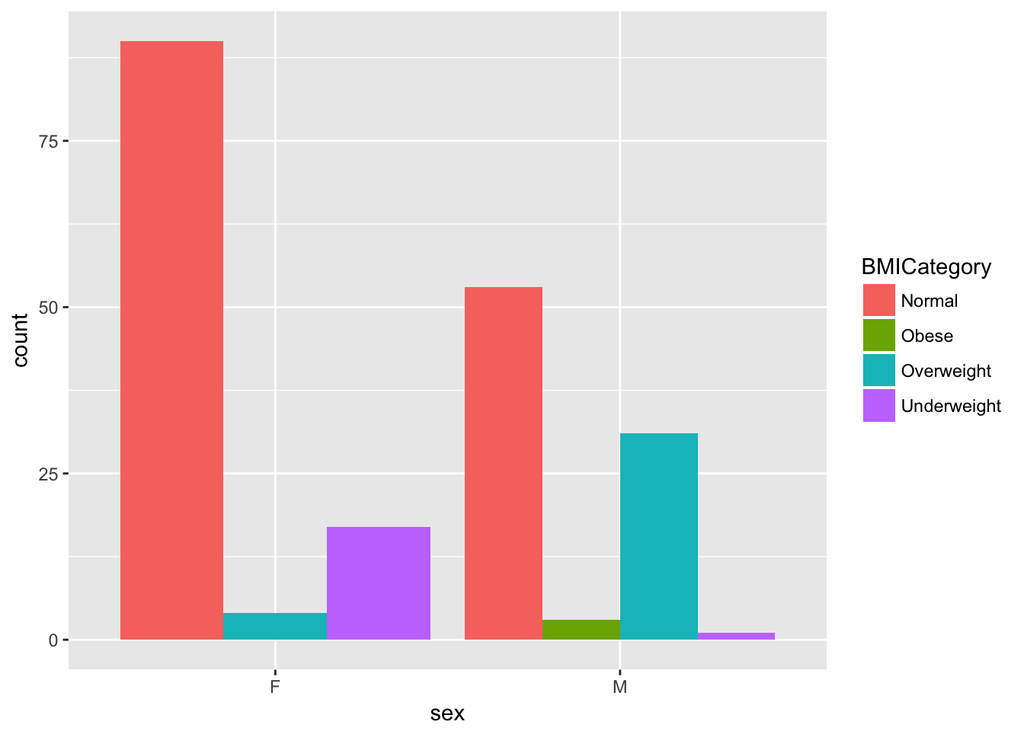

```r
  ggplot(Davis_BMI_new, aes(sex)) +
           geom_bar(aes(fill = BMICategory), position = "dodge")
```